# Risk Factor Analysis

## Outcome Variable

**Outcome Variable:** wasted

## Predictor Variables

**Intervention Variable:** fhtcm

**Adjustment Set:**

- arm
- W_mage
- W_fage
- meducyrs
- feducyrs
- W_mhtcm
- W_mwtkg
- W_mbmi
- single
- delta_W_mage
- delta_W_fage
- delta_meducyrs
- delta_feducyrs
- delta_W_mhtcm
- delta_W_mwtkg
- delta_W_mbmi
- delta_single

## Stratifying Variables

The analysis was stratified on these variable(s):

- agecat
- studyid
- country

## Data Summary

| agecat | studyid | country | fhtcm | wasted | n_cell | n |
| --- | --- | --- | --- | --- | --- | --- |
| Birth | ki1000304b-SAS-CompFeed | INDIA | >=167 cm | 0 | 46 | 90 |
| Birth | ki1000304b-SAS-CompFeed | INDIA | >=167 cm | 1 | 0 | 90 |
| Birth | ki1000304b-SAS-CompFeed | INDIA | <162 cm | 0 | 20 | 90 |
| Birth | ki1000304b-SAS-CompFeed | INDIA | <162 cm | 1 | 0 | 90 |
| Birth | ki1000304b-SAS-CompFeed | INDIA | [162-167) cm | 0 | 24 | 90 |
| Birth | ki1000304b-SAS-CompFeed | INDIA | [162-167) cm | 1 | 0 | 90 |
| Birth | ki1101329-Keneba | GAMBIA | >=167 cm | 0 | 693 | 1079 |
| Birth | ki1101329-Keneba | GAMBIA | >=167 cm | 1 | 17 | 1079 |
| Birth | ki1101329-Keneba | GAMBIA | <162 cm | 0 | 80 | 1079 |
| Birth | ki1101329-Keneba | GAMBIA | <162 cm | 1 | 1 | 1079 |
| Birth | ki1101329-Keneba | GAMBIA | [162-167) cm | 0 | 285 | 1079 |
| Birth | ki1101329-Keneba | GAMBIA | [162-167) cm | 1 | 3 | 1079 |
| Birth | ki1119695-PROBIT | BELARUS | >=167 cm | 0 | 9273 | 12474 |
| Birth | ki1119695-PROBIT | BELARUS | >=167 cm | 1 | 2411 | 12474 |
| Birth | ki1119695-PROBIT | BELARUS | <162 cm | 0 | 130 | 12474 |
| Birth | ki1119695-PROBIT | BELARUS | <162 cm | 1 | 38 | 12474 |
| Birth | ki1119695-PROBIT | BELARUS | [162-167) cm | 0 | 478 | 12474 |
| Birth | ki1119695-PROBIT | BELARUS | [162-167) cm | 1 | 144 | 12474 |
| Birth | ki1135781-COHORTS | GUATEMALA | >=167 cm | 0 | 22 | 192 |
| Birth | ki1135781-COHORTS | GUATEMALA | >=167 cm | 1 | 4 | 192 |
| Birth | ki1135781-COHORTS | GUATEMALA | <162 cm | 0 | 92 | 192 |
| Birth | ki1135781-COHORTS | GUATEMALA | <162 cm | 1 | 20 | 192 |
| Birth | ki1135781-COHORTS | GUATEMALA | [162-167) cm | 0 | 42 | 192 |
| Birth | ki1135781-COHORTS | GUATEMALA | [162-167) cm | 1 | 12 | 192 |
| 6 months | ki1000304b-SAS-CompFeed | INDIA | >=167 cm | 0 | 332 | 807 |
| 6 months | ki1000304b-SAS-CompFeed | INDIA | >=167 cm | 1 | 38 | 807 |
| 6 months | ki1000304b-SAS-CompFeed | INDIA | <162 cm | 0 | 170 | 807 |
| 6 months | ki1000304b-SAS-CompFeed | INDIA | <162 cm | 1 | 23 | 807 |
| 6 months | ki1000304b-SAS-CompFeed | INDIA | [162-167) cm | 0 | 212 | 807 |
| 6 months | ki1000304b-SAS-CompFeed | INDIA | [162-167) cm | 1 | 32 | 807 |
| 6 months | ki1000304b-SAS-FoodSuppl | INDIA | >=167 cm | 0 | 88 | 371 |
| 6 months | ki1000304b-SAS-FoodSuppl | INDIA | >=167 cm | 1 | 14 | 371 |
| 6 months | ki1000304b-SAS-FoodSuppl | INDIA | <162 cm | 0 | 115 | 371 |
| 6 months | ki1000304b-SAS-FoodSuppl | INDIA | <162 cm | 1 | 33 | 371 |
| 6 months | ki1000304b-SAS-FoodSuppl | INDIA | [162-167) cm | 0 | 101 | 371 |
| 6 months | ki1000304b-SAS-FoodSuppl | INDIA | [162-167) cm | 1 | 20 | 371 |
| 6 months | ki1101329-Keneba | GAMBIA | >=167 cm | 0 | 923 | 1510 |
| 6 months | ki1101329-Keneba | GAMBIA | >=167 cm | 1 | 56 | 1510 |
| 6 months | ki1101329-Keneba | GAMBIA | <162 cm | 0 | 104 | 1510 |
| 6 months | ki1101329-Keneba | GAMBIA | <162 cm | 1 | 9 | 1510 |
| 6 months | ki1101329-Keneba | GAMBIA | [162-167) cm | 0 | 397 | 1510 |
| 6 months | ki1101329-Keneba | GAMBIA | [162-167) cm | 1 | 21 | 1510 |
| 6 months | ki1119695-PROBIT | BELARUS | >=167 cm | 0 | 11053 | 11892 |
| 6 months | ki1119695-PROBIT | BELARUS | >=167 cm | 1 | 90 | 11892 |
| 6 months | ki1119695-PROBIT | BELARUS | <162 cm | 0 | 155 | 11892 |
| 6 months | ki1119695-PROBIT | BELARUS | <162 cm | 1 | 1 | 11892 |
| 6 months | ki1119695-PROBIT | BELARUS | [162-167) cm | 0 | 592 | 11892 |
| 6 months | ki1119695-PROBIT | BELARUS | [162-167) cm | 1 | 1 | 11892 |
| 6 months | ki1135781-COHORTS | GUATEMALA | >=167 cm | 0 | 44 | 336 |
| 6 months | ki1135781-COHORTS | GUATEMALA | >=167 cm | 1 | 0 | 336 |
| 6 months | ki1135781-COHORTS | GUATEMALA | <162 cm | 0 | 190 | 336 |
| 6 months | ki1135781-COHORTS | GUATEMALA | <162 cm | 1 | 8 | 336 |
| 6 months | ki1135781-COHORTS | GUATEMALA | [162-167) cm | 0 | 89 | 336 |
| 6 months | ki1135781-COHORTS | GUATEMALA | [162-167) cm | 1 | 5 | 336 |
| 24 months | ki1101329-Keneba | GAMBIA | >=167 cm | 0 | 743 | 1298 |
| 24 months | ki1101329-Keneba | GAMBIA | >=167 cm | 1 | 80 | 1298 |
| 24 months | ki1101329-Keneba | GAMBIA | <162 cm | 0 | 79 | 1298 |
| 24 months | ki1101329-Keneba | GAMBIA | <162 cm | 1 | 17 | 1298 |
| 24 months | ki1101329-Keneba | GAMBIA | [162-167) cm | 0 | 344 | 1298 |
| 24 months | ki1101329-Keneba | GAMBIA | [162-167) cm | 1 | 35 | 1298 |
| 24 months | ki1119695-PROBIT | BELARUS | >=167 cm | 0 | 3352 | 3609 |
| 24 months | ki1119695-PROBIT | BELARUS | >=167 cm | 1 | 35 | 3609 |
| 24 months | ki1119695-PROBIT | BELARUS | <162 cm | 0 | 50 | 3609 |
| 24 months | ki1119695-PROBIT | BELARUS | <162 cm | 1 | 2 | 3609 |
| 24 months | ki1119695-PROBIT | BELARUS | [162-167) cm | 0 | 168 | 3609 |
| 24 months | ki1119695-PROBIT | BELARUS | [162-167) cm | 1 | 2 | 3609 |
| 24 months | ki1135781-COHORTS | GUATEMALA | >=167 cm | 0 | 69 | 532 |
| 24 months | ki1135781-COHORTS | GUATEMALA | >=167 cm | 1 | 3 | 532 |
| 24 months | ki1135781-COHORTS | GUATEMALA | <162 cm | 0 | 292 | 532 |
| 24 months | ki1135781-COHORTS | GUATEMALA | <162 cm | 1 | 19 | 532 |
| 24 months | ki1135781-COHORTS | GUATEMALA | [162-167) cm | 0 | 140 | 532 |
| 24 months | ki1135781-COHORTS | GUATEMALA | [162-167) cm | 1 | 9 | 532 |

The following strata were considered:

- agecat: 24 months, studyid: ki1101329-Keneba, country: GAMBIA
- agecat: 24 months, studyid: ki1119695-PROBIT, country: BELARUS
- agecat: 24 months, studyid: ki1135781-COHORTS, country: GUATEMALA
- agecat: 6 months, studyid: ki1000304b-SAS-CompFeed, country: INDIA
- agecat: 6 months, studyid: ki1000304b-SAS-FoodSuppl, country: INDIA
- agecat: 6 months, studyid: ki1101329-Keneba, country: GAMBIA
- agecat: 6 months, studyid: ki1119695-PROBIT, country: BELARUS
- agecat: 6 months, studyid: ki1135781-COHORTS, country: GUATEMALA
- agecat: Birth, studyid: ki1000304b-SAS-CompFeed, country: INDIA
- agecat: Birth, studyid: ki1101329-Keneba, country: GAMBIA
- agecat: Birth, studyid: ki1119695-PROBIT, country: BELARUS
- agecat: Birth, studyid: ki1135781-COHORTS, country: GUATEMALA

### Dropped Strata

Some strata were dropped due to rare outcomes:

- agecat: Birth, studyid: ki1000304b-SAS-CompFeed, country: INDIA
- agecat: Birth, studyid: ki1101329-Keneba, country: GAMBIA
- agecat: Birth, studyid: ki1135781-COHORTS, country: GUATEMALA
- agecat: 6 months, studyid: ki1119695-PROBIT, country: BELARUS
- agecat: 6 months, studyid: ki1135781-COHORTS, country: GUATEMALA
- agecat: 24 months, studyid: ki1119695-PROBIT, country: BELARUS
- agecat: 24 months, studyid: ki1135781-COHORTS, country: GUATEMALA

## Methods Detail

We’re interested in the causal parameters $E[Y_a]$ for all values of $a \in \mathcal{A}$. These parameters represent the mean outcome if, possibly contrary to fact, we intervened to set all units to have $A=a$. Under the randomization and positivity assumptions, these are identified by the statistical parameters $\psi_a=E_W[E_{Y|A,W}(Y|A=a,W)]$. In addition, we’re interested in the mean of $Y$, $E[Y]$ under no intervention (the observed mean). We will estimate these parameters by using SuperLearner to fit the relevant likelihood factors – $E_{Y|A,W}(Y|A=a,W)$ and $p(A=a|W)$, and then updating our likelihood fit using a joint TMLE.

For unadjusted analyses ($W=\{\}$), initial likelihoods were estimated using Lrnr_glm to estimate the simple $E(Y|A)$ and Lrnr_mean to estimate $p(A)$. For adjusted analyses, a small library containing Lrnr_glmnet, Lrnr_xgboost, and Lrnr_mean was used.

Having estimated these parameters, we will then use the delta method to estimate relative risks and attributable risks relative to a prespecified baseline level of $A$.

# Results Detail

## Results Plots

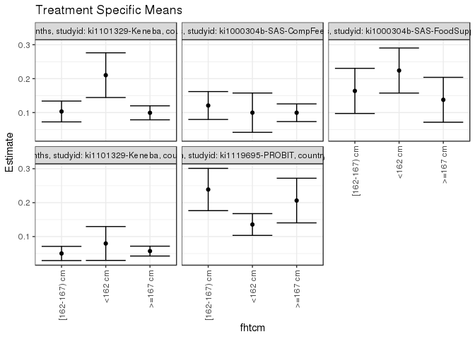

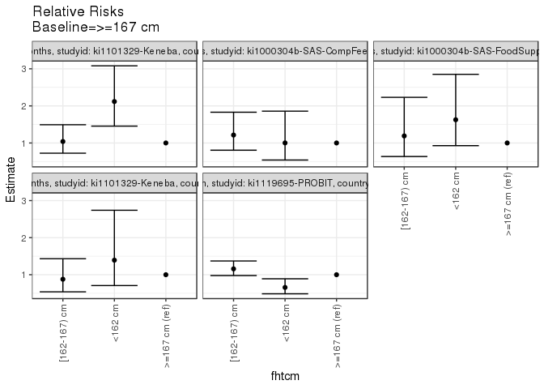

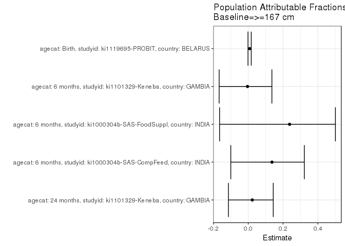

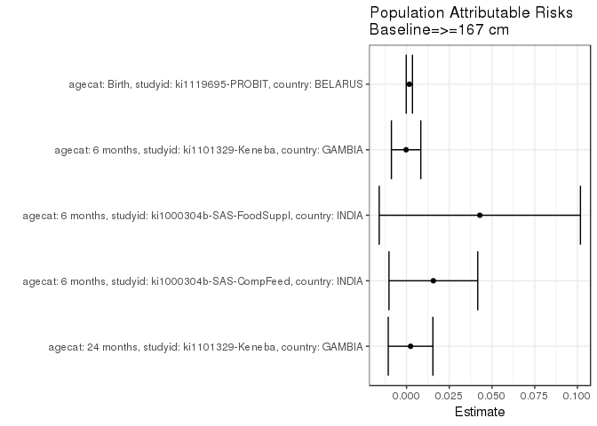

## Results Table

### Parameter: TSM

| agecat | studyid | country | intervention_level | baseline_level | estimate | ci_lower | ci_upper |
| --- | --- | --- | --- | --- | --- | --- | --- |
| Birth | ki1119695-PROBIT | BELARUS | >=167 cm | NA | 0.2062283 | 0.1404131 | 0.2720435 |
| Birth | ki1119695-PROBIT | BELARUS | <162 cm | NA | 0.1355838 | 0.1034688 | 0.1676988 |
| Birth | ki1119695-PROBIT | BELARUS | [162-167) cm | NA | 0.2387523 | 0.1764315 | 0.3010730 |
| 6 months | ki1000304b-SAS-CompFeed | INDIA | >=167 cm | NA | 0.0995400 | 0.0734468 | 0.1256332 |
| 6 months | ki1000304b-SAS-CompFeed | INDIA | <162 cm | NA | 0.0997044 | 0.0417606 | 0.1576481 |
| 6 months | ki1000304b-SAS-CompFeed | INDIA | [162-167) cm | NA | 0.1207916 | 0.0796225 | 0.1619607 |
| 6 months | ki1000304b-SAS-FoodSuppl | INDIA | >=167 cm | NA | 0.1377064 | 0.0715457 | 0.2038671 |
| 6 months | ki1000304b-SAS-FoodSuppl | INDIA | <162 cm | NA | 0.2239476 | 0.1575407 | 0.2903546 |
| 6 months | ki1000304b-SAS-FoodSuppl | INDIA | [162-167) cm | NA | 0.1638508 | 0.0972692 | 0.2304324 |
| 6 months | ki1101329-Keneba | GAMBIA | >=167 cm | NA | 0.0572012 | 0.0426496 | 0.0717529 |
| 6 months | ki1101329-Keneba | GAMBIA | <162 cm | NA | 0.0796460 | 0.0297102 | 0.1295818 |
| 6 months | ki1101329-Keneba | GAMBIA | [162-167) cm | NA | 0.0502392 | 0.0292917 | 0.0711867 |
| 24 months | ki1101329-Keneba | GAMBIA | >=167 cm | NA | 0.0993312 | 0.0787062 | 0.1199563 |
| 24 months | ki1101329-Keneba | GAMBIA | <162 cm | NA | 0.2102848 | 0.1443775 | 0.2761921 |
| 24 months | ki1101329-Keneba | GAMBIA | [162-167) cm | NA | 0.1032787 | 0.0725819 | 0.1339754 |

### Parameter: E(Y)

| agecat | studyid | country | intervention_level | baseline_level | estimate | ci_lower | ci_upper |
| --- | --- | --- | --- | --- | --- | --- | --- |
| Birth | ki1119695-PROBIT | BELARUS | NA | NA | 0.2078724 | 0.1422510 | 0.2734938 |
| 6 months | ki1000304b-SAS-CompFeed | INDIA | NA | NA | 0.1152416 | 0.0868962 | 0.1435870 |
| 6 months | ki1000304b-SAS-FoodSuppl | INDIA | NA | NA | 0.1805930 | 0.1413965 | 0.2197895 |
| 6 months | ki1101329-Keneba | GAMBIA | NA | NA | 0.0569536 | 0.0452605 | 0.0686468 |
| 24 months | ki1101329-Keneba | GAMBIA | NA | NA | 0.1016949 | 0.0852459 | 0.1181439 |

### Parameter: RR

| agecat | studyid | country | intervention_level | baseline_level | estimate | ci_lower | ci_upper |
| --- | --- | --- | --- | --- | --- | --- | --- |
| Birth | ki1119695-PROBIT | BELARUS | >=167 cm | >=167 cm | 1.0000000 | 1.0000000 | 1.000000 |
| Birth | ki1119695-PROBIT | BELARUS | <162 cm | >=167 cm | 0.6574451 | 0.4854480 | 0.890382 |
| Birth | ki1119695-PROBIT | BELARUS | [162-167) cm | >=167 cm | 1.1577086 | 0.9777799 | 1.370747 |
| 6 months | ki1000304b-SAS-CompFeed | INDIA | >=167 cm | >=167 cm | 1.0000000 | 1.0000000 | 1.000000 |
| 6 months | ki1000304b-SAS-CompFeed | INDIA | <162 cm | >=167 cm | 1.0016511 | 0.5399695 | 1.858077 |
| 6 months | ki1000304b-SAS-CompFeed | INDIA | [162-167) cm | >=167 cm | 1.2134976 | 0.8049315 | 1.829443 |
| 6 months | ki1000304b-SAS-FoodSuppl | INDIA | >=167 cm | >=167 cm | 1.0000000 | 1.0000000 | 1.000000 |
| 6 months | ki1000304b-SAS-FoodSuppl | INDIA | <162 cm | >=167 cm | 1.6262688 | 0.9273989 | 2.851793 |
| 6 months | ki1000304b-SAS-FoodSuppl | INDIA | [162-167) cm | >=167 cm | 1.1898560 | 0.6346603 | 2.230732 |
| 6 months | ki1101329-Keneba | GAMBIA | >=167 cm | >=167 cm | 1.0000000 | 1.0000000 | 1.000000 |
| 6 months | ki1101329-Keneba | GAMBIA | <162 cm | >=167 cm | 1.3923831 | 0.7077955 | 2.739111 |
| 6 months | ki1101329-Keneba | GAMBIA | [162-167) cm | >=167 cm | 0.8782895 | 0.5389064 | 1.431403 |
| 24 months | ki1101329-Keneba | GAMBIA | >=167 cm | >=167 cm | 1.0000000 | 1.0000000 | 1.000000 |
| 24 months | ki1101329-Keneba | GAMBIA | <162 cm | >=167 cm | 2.1170058 | 1.4550493 | 3.080111 |
| 24 months | ki1101329-Keneba | GAMBIA | [162-167) cm | >=167 cm | 1.0397401 | 0.7243251 | 1.492506 |

### Parameter: PAR

| agecat | studyid | country | intervention_level | baseline_level | estimate | ci_lower | ci_upper |
| --- | --- | --- | --- | --- | --- | --- | --- |
| Birth | ki1119695-PROBIT | BELARUS | >=167 cm | NA | 0.0016441 | -0.0001788 | 0.0034669 |
| 6 months | ki1000304b-SAS-CompFeed | INDIA | >=167 cm | NA | 0.0157016 | -0.0102637 | 0.0416670 |
| 6 months | ki1000304b-SAS-FoodSuppl | INDIA | >=167 cm | NA | 0.0428866 | -0.0159806 | 0.1017537 |
| 6 months | ki1101329-Keneba | GAMBIA | >=167 cm | NA | -0.0002476 | -0.0088444 | 0.0083492 |
| 24 months | ki1101329-Keneba | GAMBIA | >=167 cm | NA | 0.0023637 | -0.0107036 | 0.0154309 |

### Parameter: PAF

| agecat | studyid | country | intervention_level | baseline_level | estimate | ci_lower | ci_upper |
| --- | --- | --- | --- | --- | --- | --- | --- |
| Birth | ki1119695-PROBIT | BELARUS | >=167 cm | NA | 0.0079090 | -0.0014723 | 0.0172025 |
| 6 months | ki1000304b-SAS-CompFeed | INDIA | >=167 cm | NA | 0.1362494 | -0.1003060 | 0.3219477 |
| 6 months | ki1000304b-SAS-FoodSuppl | INDIA | >=167 cm | NA | 0.2374765 | -0.1647905 | 0.5008183 |
| 6 months | ki1101329-Keneba | GAMBIA | >=167 cm | NA | -0.0043471 | -0.1672214 | 0.1357996 |
| 24 months | ki1101329-Keneba | GAMBIA | >=167 cm | NA | 0.0232428 | -0.1139906 | 0.1435704 |